# BI-2019 Statistics Project №1

# 8 Сравнение между собой диаметра моллюсков с числом колец 5 и 15

Итак, нам предстоит провести сравнение двух групп. Именно ради этого момента мы не переводили кольца в числовой формат. Сначала узнаем, какой именно тест мы применим для сравнения. Удостоверимся в том, подчиняются ли у нас данные нормальному распределению. С помощью графиков плотностей распределения:

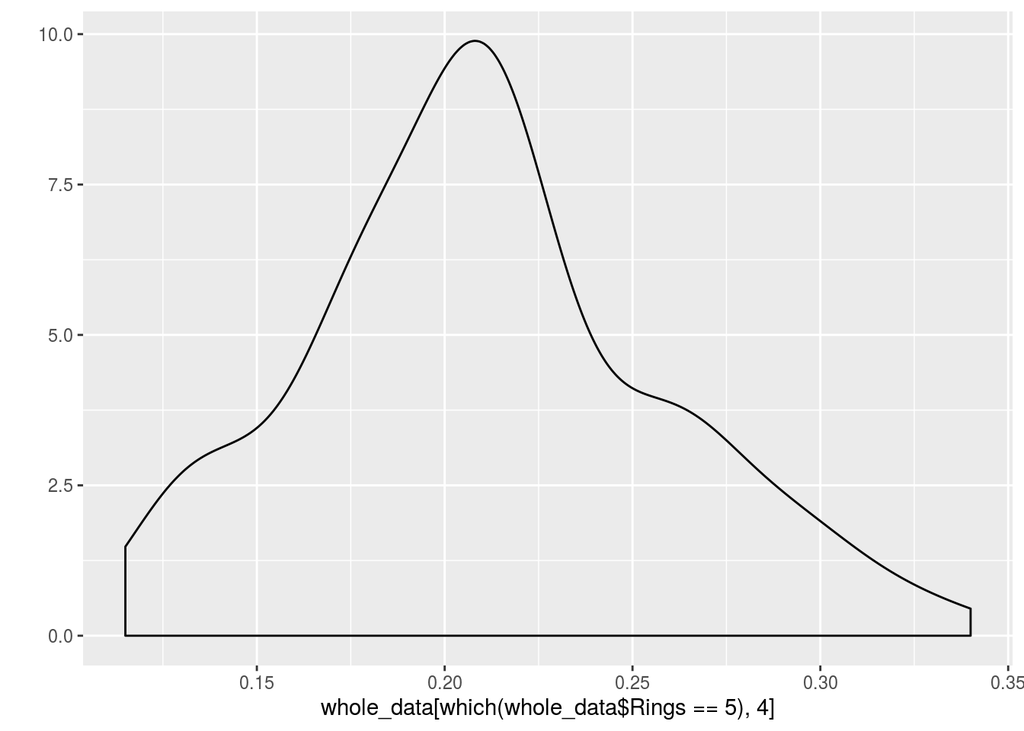

```r
qplot(whole_data[which(whole_data$Rings == 5), 4], geom = 'density')
```

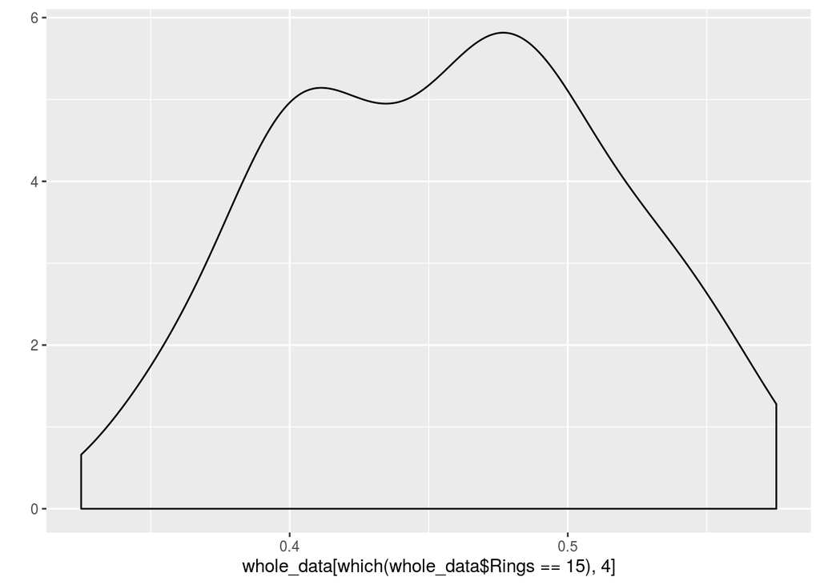

```r
qplot(whole_data[which(whole_data$Rings == 15), 4], geom = 'density')
```

И да, это довольно таки может сойти за колокола Гаусса. Пускай и неидеальные колокола.

Таким образом, мы можем смело использовать T-тест Стьюдента:

```r
t_res <- t.test(Diameter ~ Rings, whole_data[which(whole_data$Rings == 5 | whole_data$Rings == 15), ])
kable(t(tidy(t_res)), digits = c(3,3,3,3,100,3,3,3))
```

| estimate | 0.2455665 |
| --- | --- |
| estimate1 | 0.4562621 |
| estimate2 | 0.2106957 |
| statistic | 33.63632 |
| p.value | 3.379468e-83 |
| parameter | 195.3415 |
| conf.low | 0.2311683 |
| conf.high | 0.2599647 |
| method | Welch Two Sample t-test |
| alternative | two.sided |

Отлично. Мы нашли статистически значимые различия. Нарисуем к этому ещё картиночку:

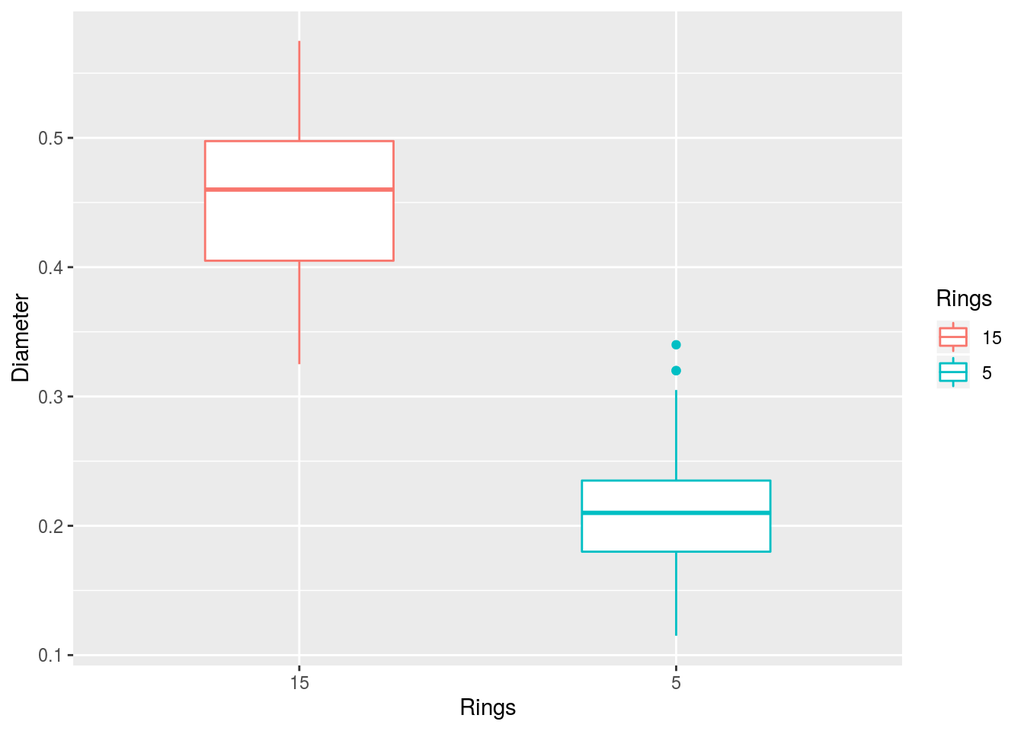

```r
ggplot(whole_data[which(whole_data$Rings == 5 | whole_data$Rings == 15), ], aes(Rings, Diameter, color = Rings)) +
  geom_boxplot(width = 0.5)
```

# 9 Связь между Diameter и Whole_weight

Выясним, подчиняются ли данные нормальному закону распределения:

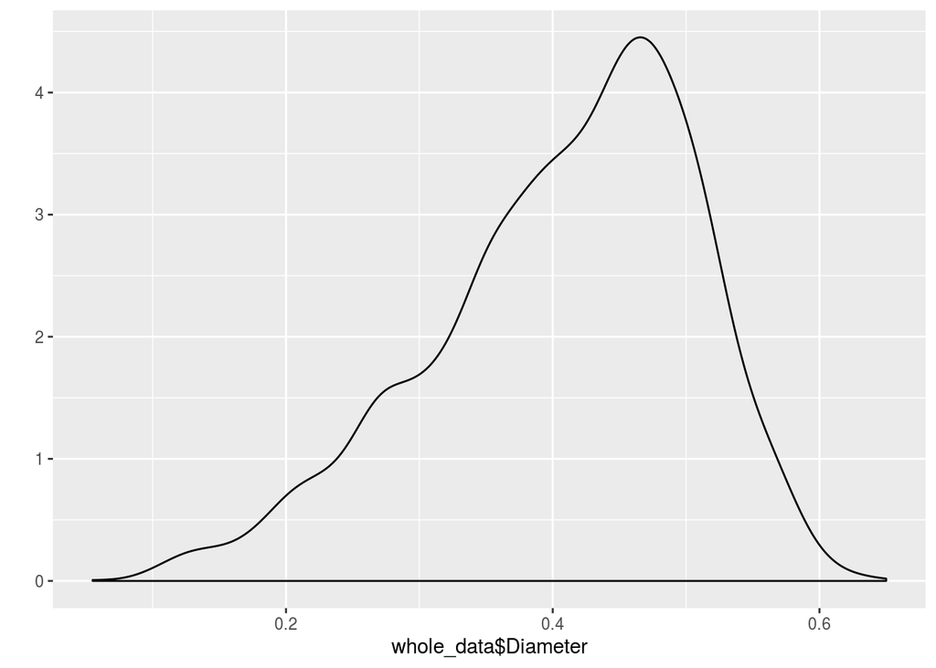

```r
qplot(whole_data$Diameter, geom = 'density')
```

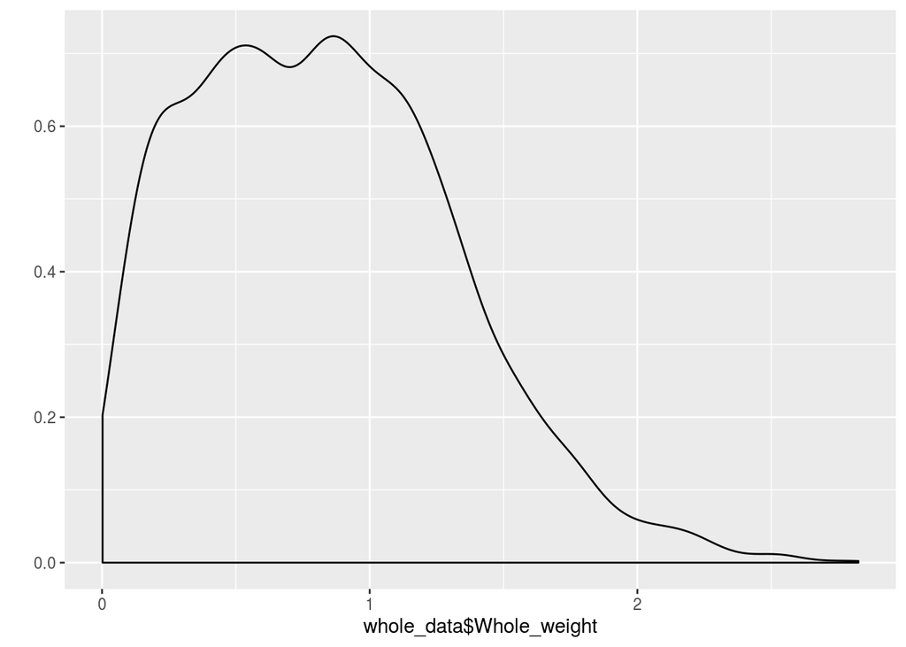

```r
qplot(whole_data$Whole_weight, geom = 'density')
```

Данные не подчиняются нормальному закону распределения. Следовательно, необходимо применить корреляцию Спирмена:

```r
cor(whole_data$Whole_weight, whole_data$Diameter, method = 'spearman')
```

```
## [1] 0.9704621
```

Действительно, мы получили число, указывающее на очень явную корреляцию. Убедимся в этом, построив график:

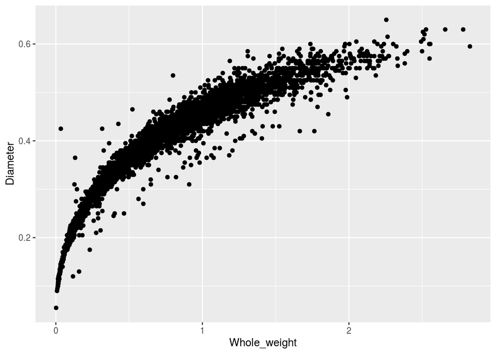

```r
ggplot(whole_data, aes(Whole_weight, Diameter)) + geom_point()
```